# Intro to Polars

Joel Herndon

Duke University Libraries  
Center for Data and Visualization Sciences

February 4, 2026

## Topics covered

01. What is polars?

02. Why polars?

03. How do I import data?

04. How can I explore my data?

05. How can I transform my data?

# 01. What is polars?

## What is Polars?

- High performance data processing library
- Works in Rust, R, and Python (plus more languages…)

# 02. Why polars?

## Why polars?

- Speed
- Expressiveness
- Strictness (consistent code)

“Come for the speed, stay for the API”  
- Janssens and Nieuwdorp, 2025

## Polars in action

## 1. Dashboards

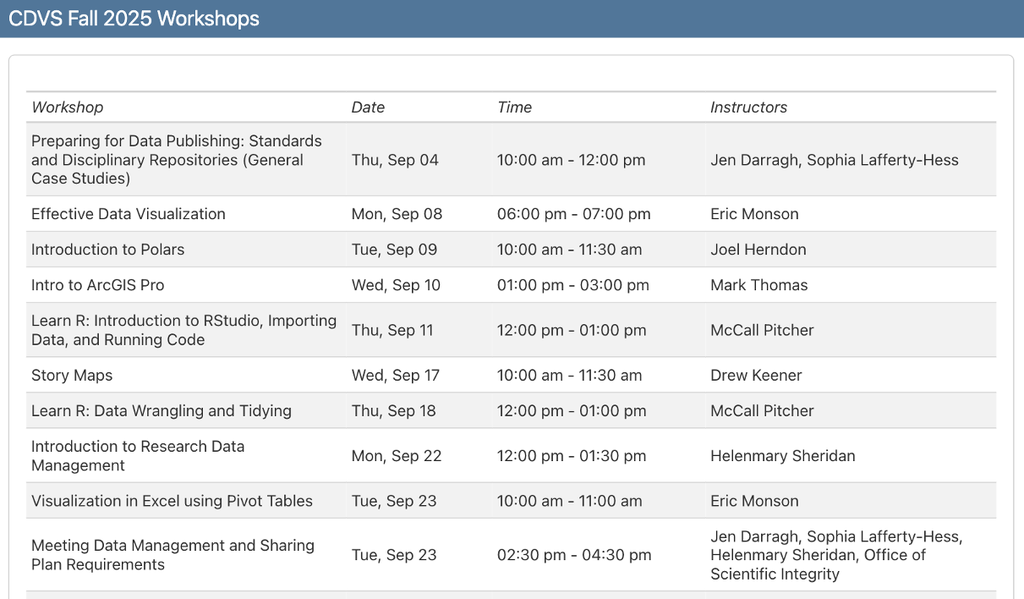

## 2. Charts

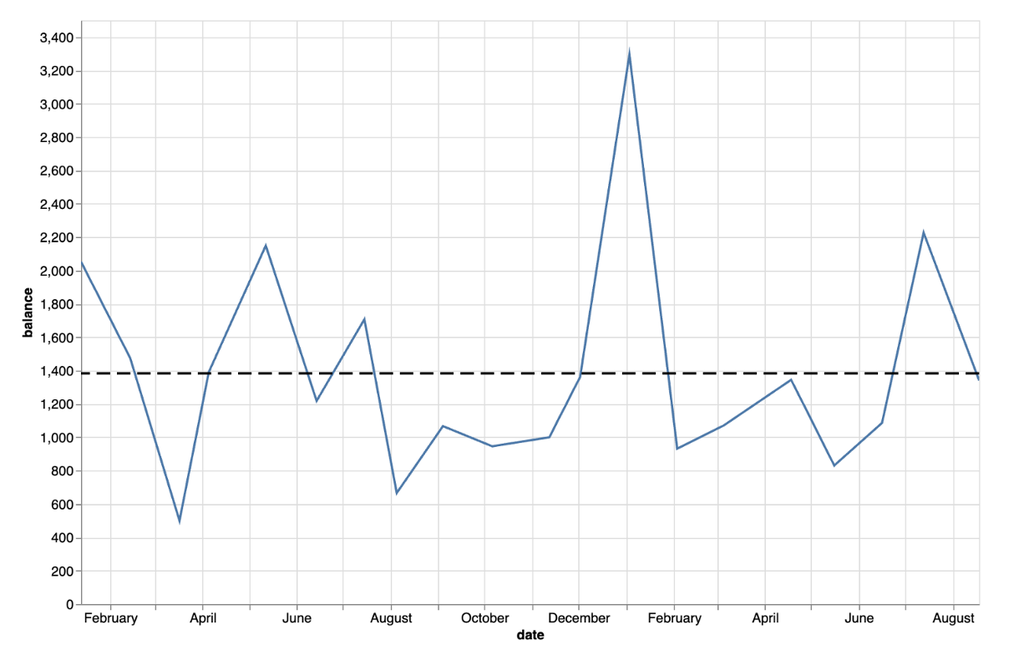

## 3. Summary tables

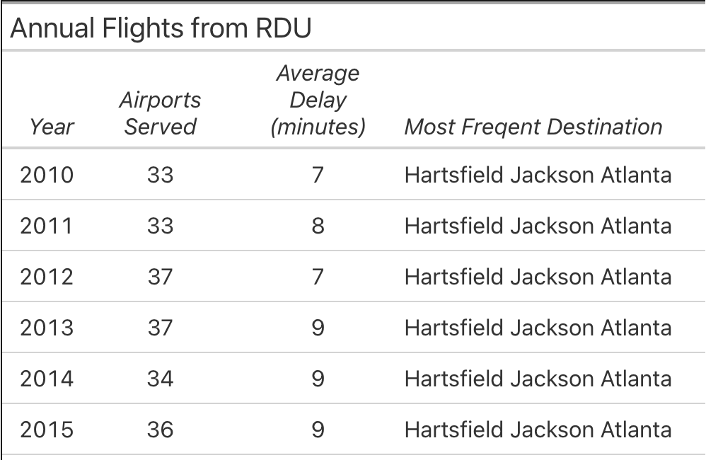

# 03. How do I import data?

## How do I import data?

- polars loads many (excel, parquet, etc.) formats
- **comma separated values** (csv) are popular
- we will focus on csv files

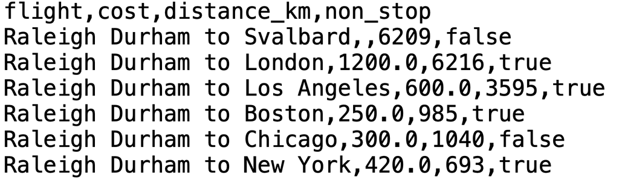

## Importing csv files

The `read_csv()` function creates polars DataFrame from a csv file.

```
import polars as pl
flights = pl.read_csv("data/flights.csv")
flights
```

## Importing csv files

shape: (6, 4)

| flight str | cost f64 | distance_km i64 | non_stop bool |
| --- | --- | --- | --- |
| "Raleigh Durham to Svalbard" | null | 6209 | false |
| "Raleigh Durham to London" | 1200.0 | 6216 | true |
| "Raleigh Durham to Los Angeles" | 600.0 | 3595 | true |
| "Raleigh Durham to Boston" | 250.0 | 985 | true |
| "Raleigh Durham to Chicago" | 300.0 | 1040 | false |
| "Raleigh Durham to New York" | 420.0 | 693 | true |

## CSV Save

The `write_csv()` function creates a csv file to preserve the data.

```
import polars as pl
flights.write_csv("data/saved_flights.csv")
```

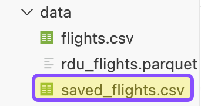

# 04. How can I explore my data?

## Exploring DataFrames

## Exploring DataFrames

01. Evaluating data size

## Evaluating size

Polars includes the `shape` of the Dataframe in its default output.

(`shape: (6,4)`)

```
flights
```

shape: (6, 4)

| flight str | cost f64 | distance_km i64 | non_stop bool |
| --- | --- | --- | --- |
| "Raleigh Durham to Svalbard" | null | 6209 | false |
| "Raleigh Durham to London" | 1200.0 | 6216 | true |
| "Raleigh Durham to Los Angeles" | 600.0 | 3595 | true |
| "Raleigh Durham to Boston" | 250.0 | 985 | true |
| "Raleigh Durham to Chicago" | 300.0 | 1040 | false |
| "Raleigh Durham to New York" | 420.0 | 693 | true |

## Evaluating size

You can also check the properties of a DataFrame programmatically:

**`height`** for a count of rows

```python
flights.height
```

```
6
```

**`width`** for a count of columns

```python
flights.width
```

```
4
```

## Evaluating size

You can also check the properties of a DataFrame programmatically:

**`shape`** for height and rows

```python
flights.shape
```

```
(6, 4)
```

## Exploring DataFrames

01. Evaluating size

02. Browsing

## Browsing

**`head()`** list the first five rows of data

```python
flights.head()
```

shape: (5, 4)

| flight str | cost f64 | distance_km i64 | non_stop bool |
| --- | --- | --- | --- |
| "Raleigh Durham to Svalbard" | null | 6209 | false |
| "Raleigh Durham to London" | 1200.0 | 6216 | true |
| "Raleigh Durham to Los Angeles" | 600.0 | 3595 | true |
| "Raleigh Durham to Boston" | 250.0 | 985 | true |
| "Raleigh Durham to Chicago" | 300.0 | 1040 | false |

## Browsing

**`tail()`** list the final five rows of data

```python
flights.tail()
```

shape: (5, 4)

| flight str | cost f64 | distance_km i64 | non_stop bool |
| --- | --- | --- | --- |
| "Raleigh Durham to London" | 1200.0 | 6216 | true |
| "Raleigh Durham to Los Angeles" | 600.0 | 3595 | true |
| "Raleigh Durham to Boston" | 250.0 | 985 | true |
| "Raleigh Durham to Chicago" | 300.0 | 1040 | false |
| "Raleigh Durham to New York" | 420.0 | 693 | true |

## Browsing

By default, Polars will print the first and last 5 rows of a DataFrame when printed.  
If you want to see more rows:

```python
pl.Config.set_tbl_rows(100) # increase the default rows printed to 100
```

```
polars.config.Config
```

## Exploring

01. Evaluating data size

02. Browsing DataFrames

03. Understanding columns

## Understanding columns

**`columns`** lists the column names

```python
flights.columns
```

```
['flight', 'cost', 'distance_km', 'non_stop']
```

**`schema`** lists columns names and data types

```python
flights.schema
```

```
Schema([('flight', String),
        ('cost', Float64),
        ('distance_km', Int64),
        ('non_stop', Boolean)])
```

## Exploring DataFrames

01. Evaluating data size

02. Browsing

03. Understanding columns

04. Considering descriptive statistics

## Descriptive statistics

Often, we want to assess the associated statistics for each column.

**`describe()`** provides descriptive statistics for DataFrames

```
flights.describe()
```

shape: (9, 5)

| statistic str | flight str | cost f64 | distance_km f64 | non_stop f64 |
| --- | --- | --- | --- | --- |
| "count" | "6" | 5.0 | 6.0 | 6.0 |
| "null_count" | "0" | 1.0 | 0.0 | 0.0 |
| "mean" | null | 554.0 | 3123.0 | 0.666667 |
| "std" | null | 385.460763 | 2612.571989 | null |
| "min" | "Raleigh Durham to Boston" | 250.0 | 693.0 | 0.0 |
| "25%" | null | 300.0 | 985.0 | null |
| "50%" | null | 420.0 | 3595.0 | null |
| "75%" | null | 600.0 | 6209.0 | null |
| "max" | "Raleigh Durham to Svalbard" | 1200.0 | 6216.0 | 1.0 |

## Exploring data

01. Evaluating data size

02. Browsing

03. Understanding columns

04. Considering descriptive statistics

05. Handling missing data

## Missing data

- Polars represents missing data as `null`.
- Polars excludes missing data from calculations

```python
flights.head(1)
```

shape: (1, 4)

| flight str | cost f64 | distance_km i64 | non_stop bool |
| --- | --- | --- | --- |
| "Raleigh Durham to Svalbard" | null | 6209 | false |

# 05. How can I transform my data?

## Five essential data wrangling verbs

| Task | polars “verb” |
| --- | --- |
| Subset columns | `select()` |
| Subset rows | `filter()` |
| Sort | `sort()` |
| Create a new variable | `with_columns()` |
| Aggregate by groups | `group_by()` |

## … and one essential function

`pl.col()`

- `pl.col()` will select one or more columns
- `pl.com()` will work with **all** of our polars verbs

## 5.1. Subset columns with select()

- `select()` chooses columns
- The `flights` DataFrame has four columns.
- Let’s select `flight` and `cost`

| column | description |
| --- | --- |
| flight | destination of RDU flight |
| cost | cost of flight |
| distance_km | distance in km |
| non_stop | is flight non-stop |

## 5.1. Subset columns with select()

```python
flights.select(pl.col('flight','cost'))
```

shape: (6, 2)

| flight str | cost f64 |
| --- | --- |
| "Raleigh Durham to Svalbard" | null |
| "Raleigh Durham to London" | 1200.0 |
| "Raleigh Durham to Los Angeles" | 600.0 |
| "Raleigh Durham to Boston" | 250.0 |
| "Raleigh Durham to Chicago" | 300.0 |
| "Raleigh Durham to New York" | 420.0 |

**Note that the columns return in the order that I request them.

## 5.1. Subset columns with select()

Often using the `drop()` method to remove columns is more efficient than `select()`.

```python
flights.drop(pl.col('cost'))
```

shape: (6, 3)

| flight str | distance_km i64 | non_stop bool |
| --- | --- | --- |
| "Raleigh Durham to Svalbard" | 6209 | false |
| "Raleigh Durham to London" | 6216 | true |
| "Raleigh Durham to Los Angeles" | 3595 | true |
| "Raleigh Durham to Boston" | 985 | true |
| "Raleigh Durham to Chicago" | 1040 | false |
| "Raleigh Durham to New York" | 693 | true |

## 5.1. Subset columns with select()

- `select()` reduces the DataFrame to the essential columns and improves perfomance.
- Polars offers numerous options for more precise selections including:
  - **Regular Expressions**: `flights.select(pl.col('^c.*$'))` # columns starting with “c”
  - **Select by data type**: `flights.select(df.select(pl.col(pl.Int64))`
  - **Slicing** (not recommended, but possible!): `flights[:]`

## 5.2 Subset rows with filter()

The `filter` command identifies rows that you wish to include in a dataframe.

```python
flights.filter(pl.col('non_stop'))
```

shape: (4, 4)

| flight str | cost f64 | distance_km i64 | non_stop bool |
| --- | --- | --- | --- |
| "Raleigh Durham to London" | 1200.0 | 6216 | true |
| "Raleigh Durham to Los Angeles" | 600.0 | 3595 | true |
| "Raleigh Durham to Boston" | 250.0 | 985 | true |
| "Raleigh Durham to New York" | 420.0 | 693 | true |

## 5.2 Subset rows with filter()

Let’s say that we wanted only the flights from RDU that were:

- a distance less than 1000 kilometers

```python
flights.filter(pl.col('distance_km') < 1000)
```

shape: (2, 4)

| flight str | cost f64 | distance_km i64 | non_stop bool |
| --- | --- | --- | --- |
| "Raleigh Durham to Boston" | 250.0 | 985 | true |
| "Raleigh Durham to New York" | 420.0 | 693 | true |

**So, our Boston and New York flights are both under 1000 kilometers from Durham.

## 5.2 Subset rows with filter()

Polars also has convenient tools for finding text:

- Is there a flight to Svalbard?

```python
flights.filter(pl.col('flight').str.contains("Svalbard"))
```

shape: (1, 4)

| flight str | cost f64 | distance_km i64 | non_stop bool |
| --- | --- | --- | --- |
| "Raleigh Durham to Svalbard" | null | 6209 | false |

## 5.2 Subset rows with filter()

Polars allows complex filter queries by combining multiple conditions using boolean expressions. For most operations, you will use the following operators to build these expressions.

| Operator | Symbol |
| --- | --- |
| AND | & |
| OR | \| |
| NOT | ~ |

## 5.2 Subset rows with filter()

Let’s say that we want to see all the flights that are:

- less than 6000 kilometers from Durham
- less than $500

## 5.2 Subset rows with filter()

- less than 6000 kilometers from Durham
- less than $500

```
flights.filter(
    (pl.col('distance_km')<6000) &
    (pl.col('cost')< 500.00)
)
```

shape: (3, 4)

| flight str | cost f64 | distance_km i64 | non_stop bool |
| --- | --- | --- | --- |
| "Raleigh Durham to Boston" | 250.0 | 985 | true |
| "Raleigh Durham to Chicago" | 300.0 | 1040 | false |
| "Raleigh Durham to New York" | 420.0 | 693 | true |

## 5.2 Subset rows with filter()

Final thoughts on `filter`-ing:

1. Polars requires explicit conditions
2. Polars requires you to enclose each condition in parentheses.
3. Using software that highlights parentheses can be helpful.

## 5.3 sort()

`sort()` allows us to specify how the rows in the DataFrame should be ordered.

## 5.3 sort()

Let’s try a simple sort based on our filtered data.

- We will sort by distance for non-stop flights.

```python
flights.filter(pl.col('non_stop')).sort(pl.col('distance_km'))
```

shape: (4, 4)

| flight str | cost f64 | distance_km i64 | non_stop bool |
| --- | --- | --- | --- |
| "Raleigh Durham to New York" | 420.0 | 693 | true |
| "Raleigh Durham to Boston" | 250.0 | 985 | true |
| "Raleigh Durham to Los Angeles" | 600.0 | 3595 | true |
| "Raleigh Durham to London" | 1200.0 | 6216 | true |

## 5.3 sort()

In the above, note how `sort` defaults to ascending order.

- If you want to sort in descending order:

```python
(
flights
  .filter(pl.col('non_stop'))
  .sort(pl.col('distance_km'), descending=True)
)
```

shape: (4, 4)

| flight str | cost f64 | distance_km i64 | non_stop bool |
| --- | --- | --- | --- |
| "Raleigh Durham to London" | 1200.0 | 6216 | true |
| "Raleigh Durham to Los Angeles" | 600.0 | 3595 | true |
| "Raleigh Durham to Boston" | 250.0 | 985 | true |
| "Raleigh Durham to New York" | 420.0 | 693 | true |

## 5.3 sort()

It is entirely possible to specify more than one column for a sort. - Let’s look at our non-stop flights sort by the cost and the distance.

```python
(
flights
    .filter(pl.col('non_stop'))
    .sort(
        [
          pl.col('cost'),
          pl.col('distance_km')
        ],
        descending=[True, False]
    )
)
```

shape: (4, 4)

| flight str | cost f64 | distance_km i64 | non_stop bool |
| --- | --- | --- | --- |
| "Raleigh Durham to London" | 1200.0 | 6216 | true |
| "Raleigh Durham to Los Angeles" | 600.0 | 3595 | true |
| "Raleigh Durham to New York" | 420.0 | 693 | true |
| "Raleigh Durham to Boston" | 250.0 | 985 | true |

## 5.3 sort()

If you have missing data in a sort column, it will be listed first.

```python
flights.sort(pl.col('cost'), descending=True)
```

shape: (6, 4)

| flight str | cost f64 | distance_km i64 | non_stop bool |
| --- | --- | --- | --- |
| "Raleigh Durham to Svalbard" | null | 6209 | false |
| "Raleigh Durham to London" | 1200.0 | 6216 | true |
| "Raleigh Durham to Los Angeles" | 600.0 | 3595 | true |
| "Raleigh Durham to New York" | 420.0 | 693 | true |
| "Raleigh Durham to Chicago" | 300.0 | 1040 | false |
| "Raleigh Durham to Boston" | 250.0 | 985 | true |

## 5.3 sort()

Show `null` values last by adding the `nulls_last=True` parameter:

```python
flights.sort(pl.col('cost'), descending=True, nulls_last=True)
```

shape: (6, 4)

| flight str | cost f64 | distance_km i64 | non_stop bool |
| --- | --- | --- | --- |
| "Raleigh Durham to London" | 1200.0 | 6216 | true |
| "Raleigh Durham to Los Angeles" | 600.0 | 3595 | true |
| "Raleigh Durham to New York" | 420.0 | 693 | true |
| "Raleigh Durham to Chicago" | 300.0 | 1040 | false |
| "Raleigh Durham to Boston" | 250.0 | 985 | true |
| "Raleigh Durham to Svalbard" | null | 6209 | false |

## 5.4 with_columns()

`with_columns()` provides a convenient way to add columns to DataFrames.

- First, we assign a column name using “*keyword argument syntax*” (*cost_per_kilometer*)
- Then we calculate the cost per kilometer

```python
flights.with_columns(
   cost_per_kilometer = pl.col('cost') / pl.col('distance_km')
)
```

shape: (6, 5)

| flight str | cost f64 | distance_km i64 | non_stop bool | cost_per_kilometer f64 |
| --- | --- | --- | --- | --- |
| "Raleigh Durham to Svalbard" | null | 6209 | false | null |
| "Raleigh Durham to London" | 1200.0 | 6216 | true | 0.19305 |
| "Raleigh Durham to Los Angeles" | 600.0 | 3595 | true | 0.166898 |
| "Raleigh Durham to Boston" | 250.0 | 985 | true | 0.253807 |
| "Raleigh Durham to Chicago" | 300.0 | 1040 | false | 0.288462 |
| "Raleigh Durham to New York" | 420.0 | 693 | true | 0.606061 |

## 5.4 with_columns()

Polars only makes changes to dataframes permanent when you save the change.

- Even though I calculated “cost_per_kilometer” on the last slide…
- The column was not added to the DataFrame (any guesses as to why?)

```python
flights
```

shape: (6, 4)

| flight str | cost f64 | distance_km i64 | non_stop bool |
| --- | --- | --- | --- |
| "Raleigh Durham to Svalbard" | null | 6209 | false |
| "Raleigh Durham to London" | 1200.0 | 6216 | true |
| "Raleigh Durham to Los Angeles" | 600.0 | 3595 | true |
| "Raleigh Durham to Boston" | 250.0 | 985 | true |
| "Raleigh Durham to Chicago" | 300.0 | 1040 | false |
| "Raleigh Durham to New York" | 420.0 | 693 | true |

## 5.4 with_columns()

Polars only makes changes to dataframes permanent when you save the change.

- Let’s save the `cost_per_kilometer` permanently to our DataFrame.
- Note that this example assigns the output to `flights`:

```python
flights = flights.with_columns(
   cost_per_kilometer = pl.col('cost') / pl.col('distance_km')
)
flights.head(3)
```

shape: (3, 5)

| flight str | cost f64 | distance_km i64 | non_stop bool | cost_per_kilometer f64 |
| --- | --- | --- | --- | --- |
| "Raleigh Durham to Svalbard" | null | 6209 | false | null |
| "Raleigh Durham to London" | 1200.0 | 6216 | true | 0.19305 |
| "Raleigh Durham to Los Angeles" | 600.0 | 3595 | true | 0.166898 |

## 5.4 with_columns()

Polars offers a second syntax style for creating columns.

- *Expression based syntax* assigns the column name using the `.alias()` method.

```python
flights = flights.with_columns(
   (pl.col('cost') / pl.col('distance_km'))
   .alias('cost_per_kilometer')
)
flights
```

shape: (6, 5)

| flight str | cost f64 | distance_km i64 | non_stop bool | cost_per_kilometer f64 |
| --- | --- | --- | --- | --- |
| "Raleigh Durham to Svalbard" | null | 6209 | false | null |
| "Raleigh Durham to London" | 1200.0 | 6216 | true | 0.19305 |
| "Raleigh Durham to Los Angeles" | 600.0 | 3595 | true | 0.166898 |
| "Raleigh Durham to Boston" | 250.0 | 985 | true | 0.253807 |
| "Raleigh Durham to Chicago" | 300.0 | 1040 | false | 0.288462 |
| "Raleigh Durham to New York" | 420.0 | 693 | true | 0.606061 |

## 5.5 group_by()

`group_by()` groups rows defined by one or more variables.

- Note that `group_by()` requires additional code to use the groupings!

```python
flights.group_by(pl.col('non-stop'))
```

```
<polars.dataframe.group_by.GroupBy at 0x107a50830>
```

## 5.5 group_by()

How many flights are non-stop (true) and “multi-stop” (false)?

- `group_by()` combined with `.agg()` (think “agregate”) then `pl.len()` (length) will count grouped observations

```python
flights.group_by(pl.col('non_stop')).agg(pl.len())
```

shape: (2, 2)

| non_stop bool | len u32 |
| --- | --- |
| true | 4 |
| false | 2 |

## 5.5 group_by()

You can perform multiple operations on a selection.

- Calculate the mean distance for direct and indirect flights
- Rename the calculated column: `average_distance_km` (use `alias`)

```python
(
flights.group_by(pl.col('non_stop'))
    .agg(
        pl.col('distance_km').mean().alias('average_distance_km')
    )
)
```

shape: (2, 2)

| non_stop bool | average_distance_km f64 |
| --- | --- |
| false | 3624.5 |
| true | 2872.25 |

## 5.6 over()

I know…

I said I was only going to show you five common “verbs” in Polars…

- `group_by()` provides a convenient way to “collapse” data into groups…
- sometimes you want the group calculation in the *original* DataFrame…
- This is where the `over()` method comes in handy.

## 5.6 over()

Let’s calculate the average distance **over** non-stop and multi-stop flights. - We will insert the calculation for each group in the DataFrame.

```python
(
flights.
  with_columns(pl.col('distance_km')
    .mean()
    .over(pl.col('non_stop'))
    .alias('average_distance_km'))
  .select(pl.col('flight','non_stop','average_distance_km'))
)
```

## 5.6 over()

shape: (6, 3)

| flight str | non_stop bool | average_distance_km f64 |
| --- | --- | --- |
| "Raleigh Durham to Svalbard" | false | 3624.5 |
| "Raleigh Durham to London" | true | 2872.25 |
| "Raleigh Durham to Los Angeles" | true | 2872.25 |
| "Raleigh Durham to Boston" | true | 2872.25 |
| "Raleigh Durham to Chicago" | false | 3624.5 |
| "Raleigh Durham to New York" | true | 2872.25 |

# 06. Polars in practice

## Big data and Polars

- Let’s explore a large dataset!
  - Roughly 1 million rows of FAA air travel data
  - Raleigh Durham (RDU) airport from 2010 to 2024
  - Special thanks to Simon Couch and colleagues for the “anyflights” package used to secure these data (see final slides for details)

## Loading our RDU flights data

If using VSCode or Python IDE:

```
import polars as pl
rdu_flights = pl.read_parquet("rdu_flights.parquet")
```

If you are using Google Colab:

```
import polars as pl
from google.colab import files
files.upload() # choose rdu_flights.parquet
rdu_flights = pl.read_parquet("rdu_flights.parquet")
```

**NOTE** - you will need to specify the path to the data

## 1. Exploring our RDU flights data

- How many rows and columns in this Dataframe?
- `rdu_flights.shape`
- `rdu_flights.height` and `rdu_flights.width` will also give you the answer
- The answer: `(954988, 45)`

## 2. Departing flights by year

How many flights depart RDU airport by year? (Bonus: sort by year)

- `rdu_flights.group_by('year').agg(pl.len().alias('flights'))`

## 2. Departing flights by year

```python
(
rdu_flights
  .group_by('year')
  .agg(pl.len().alias('flights'))
  .sort('year')
)
```

## 2. Departing flights by year

shape: (15, 2)

| year i64 | flights u32 |
| --- | --- |
| 2010 | 48924 |
| 2011 | 42620 |
| 2012 | 44016 |
| 2013 | 47983 |
| 2014 | 38813 |
| 2015 | 34898 |
| 2016 | 104895 |
| 2017 | 71874 |
| 2018 | 121448 |
| 2019 | 128312 |
| 2020 | 67720 |
| 2021 | 44136 |
| 2022 | 54049 |
| 2023 | 59416 |
| 2024 | 45884 |

## 3. Departure delays by year

- Are departure delays increasing or decreasing at RDU each year?

## 3. Departure delays by year

Are departure delays increasing or decreasing at RDU each year?

```python
(
rdu_flights
    .group_by('year')
    .agg(pl.col('dep_delay')
        .filter(pl.col('dep_delay') > 15)
        .len()
        .alias('delayed_flights')
    )
    .sort('year')
)
```

## 3. Departure delays by year

shape: (15, 2)

| year i64 | delayed_flights u32 |
| --- | --- |
| 2010 | 7339 |
| 2011 | 6234 |
| 2012 | 6099 |
| 2013 | 8003 |
| 2014 | 6757 |
| 2015 | 5623 |
| 2016 | 16182 |
| 2017 | 11952 |
| 2018 | 23592 |
| 2019 | 23146 |
| 2020 | 5082 |
| 2021 | 5674 |
| 2022 | 9896 |
| 2023 | 10762 |
| 2024 | 9260 |

# 04. Polars resources

## General Resources

- *CDVS - Duke Libraries - askdata@duke.edu*  
  As always, Duke Libraries Center for Data and Visualization Science (askdata@duke.edu) can assist with questions about data management and data wrangling. Consultations are available by appointment.
- *Polars API*  
  The [Polars Python API](https://docs.pola.rs/api/python/stable/reference/index.html) is an outstanding resource for the latest syntax. If you are questioning the validity of AI suggestions (and sometimes those suggestions are erroneous!), the API can help resolve questions.

## eBook Resources

Duke Libraries subscribe to the [O’Reilly for Higher Education](https://go.oreilly.com/duke-university) Database where you will find Jeroen Janssens and Thijs Nieuwdorp’s [Python Polars: The Definitive Guide](https://learning.oreilly.com/library/view/python-polars-the/9781098156077/). This is an excellent way to learn Polars and serves as compelling reference.

## Data Resources

I used FAA flight data pulled using the anyflights API. If you would like to investigate this API further check out:

Couch S (2023). anyflights: Query ‘nycflights13’- Air Travel Data for Given Years and Airports. [Code: https://github.com/simonpcouch/anyflights](https://github.com/simonpcouch/anyflights), [Context: https://simonpcouch.github.io/anyflights/](https://simonpcouch.github.io/anyflights/).

## Other polars APIs

As mentioned in the introduction, [Polars](https://pola.rs/) is written in [Rust](https://rust-lang.org/) and has implementations in Julia, R (check out [TidyPolars](https://tidypolars.etiennebacher.com/) , and Javascript. If Polars seems compelling and you regularly use one of those languages, please try one of the other implementations!

## Thank you!

- *CDVS - Duke Libraries - askdata@duke.edu*
- *Joel Herndon - joel.herndon@duke.edu*